# Reglas de Asociación

# Introducción

La minería de las reglas de asociación es un área muy importante dentro de la minería de datos. Es un proceso no supervisado que tiene la finalidad de encontrar las reglas de asociación que se encuentran en las instancias de base de datos, su principal desarrollo ha sido en el área de los negocios,la base de datos que analiza la minería de las reglas de asociación son las transacciones que quedan registradas en una base de datos, en cada una de las transacciones el cliente lleva cierta cantidad de artículos de la canasta de artículos de venta que tiene ese negocio , con esta información capturada, los algoritmos de minería de las reglas de asociación, lleva a cabo un análisis en donde determina cuales artículos se venden unos con otros, de esta asociación de artículos (ítem) se obtienen las reglas de asociación, debido a la gran cantidad de artículos que están tiendas tienen, existe una explosión de las reglas que se pueden generar, para obtener solamente las reglas más importantes se usan dos parámetros, el soporte mínimo y la confianza mínima que sirven para seleccionar cuales son las reglas de asociación más interesantes.

## Reglas de Asociación

Una regla de asociación es una implicación de la forma $A \rightarrow B$ ,esta regla de asociación dice que cuando se compra el ítem $A$ es probable que se compre el ítem $B$, tanto $A$ como $B$ pueden estar formados por uno o varios ítems. Otra interpretación que se le puede dar a la regla $A \rightarrow B$ es que cuando se cumple la condición $A$ se lleva a cabo la acción $B$.

## Soporte y Confianza

El soporte y la confianza son parámetros importantes, para ello se define: $ X Y$, donde $X$ e $Y$ son conjuntos de ítems.

### Soporte

El soporte de $X \rightarrow Y$ es el porcentaje de las transacciones que contienen todos los ítems de $X$ e $Y$.

Además se tiene que:

Soporte$(X \rightarrow Y)=$ $P(X \cup Y)=$ Soporte $(X \cup Y)$

### Confianza

La confianza para $X \rightarrow Y$ es el porcentaje de transacciones que contienen $Y$, entre las transacciones que contienen $X$.

Además se tiene que:

Confianza $X \rightarrow Y=$ $P(Y/X)=\frac{Soporte(X \cup Y)}{Soporte (X)}$

## Paquete arules

El paquete de R arules implementa el algoritmo Apriori para la identificación de itemsets frecuentes y la creación de reglas de asociación a través de la función apriori(). También implementa el algoritmo Eclat con la función eclat().Tanto apriori() como eclat() reciben como argumento un objeto transaction con los datos de las transacciones.

## Algoritmo A priori

El proceso del algoritmo Apriori empieza con la obtención de los llamados conjuntos de ítems frecuentes, los cuales son aquellos conjuntos formados por los ítems cuyo soporte obtenido de la base de datos es superior al soporte mínimo solicitado por el usuario. Debido al amplio uso del algoritmo Apriori, desde que se formalizó la inducción de reglas de asociación, la obtención de los conjuntos de ítems frecuentes es una tarea común en dichos algoritmos.

## Algoritmo Eclat

En el 2000, Zaki propuso un nuevo algoritmo para encontrar patrones frecuentes (itemsets frecuentes) llamado Equivalence Class Transformation (Eclat). La principal diferencia entre este algoritmo y Apriori es la forma en que se escanean y analizan los datos. El algoritmo Apriori emplea transacciones almacenadas de forma horizontal, es decir, todos los elementos que forman una misma transacción están en la misma línea. El algoritmo Eclat, sin embargo, analiza las transacciones en formato vertical, donde cada línea contiene un item y las transacciones en las que aparece ese item.

# Desarrollo

En el presente trabajo se tiene una base de datos de órdenes que contiene 12500 pedidos (transacciones) en un establecimiento donde se venden alimentos.

```
##   order_id          product_name
## 1        2    Organic Egg Whites
## 2        2 Michigan Organic Kale
## 3        2         Garlic Powder
## 4        2        Coconut Butter
## 5        2     Natural Sweetener
## 6        2               Carrots
```

Cada línea del archivo contiene la información de un item y el identificador de la transacción (compra) a la que pertenece. Esta es la estructura en la que comúnmente se almacenan los datos dentro de una base de datos y que, en el ámbito de las transacciones, recibe el nombre de tabla larga o single.

Para este caso de estudio, compras de alimentos, cada transacción está formada por todos los productos que se compran a la vez, es decir, el vínculo de unión no es el cliente sino cada una de los productos que compra .Por ejemplo se tiene que en la orden 68 se ha pedido 9 productos:

```
## [1] "Variety Diet Tea"      "Seltzer Water"         "Gourmet Tomato Medley"
## [4] "Granny Smith Apples"   "Soda"                  "Ginger Dressing"
## [7] "Non Fat Greek Yogurt"  "Migraine Caplets"      "Blackberries"
```

## Lectura y Comprensión de Datos

Con la función read.transactions() se pueden leer directamente los datos de archivos tipo texto y almacenarlos en un objeto de tipo transactions, que es la estructura de almacenamiento que emplea el paquete arules.Es importante recordar que los objetos de tipo transactions solo trabajan con información booleana, es decir, con la presencia o no de cada uno de los items en la transacción.

```
## transactions in sparse format with
##  12500 transactions (rows) and
##  17917 items (columns)
```

Ahora se tiene el objeto transacciones donde en las comlumnas se encuentran los productos que son 17917 y en las filas el código de la transacción y en total son 12500.

## Exploración de ítems

Para observar de mejor manera las transacciones que se realizan, se puede observar el número de ítems que lo forman y cuáles son, por ejemplo:

```
##     items                                                                                      transactionID
## [1] {Soda,
##      Spring Water}                                                                                      100
## [2] {Cacao Sweet Raw Chocolate Nibs,
##      Jazz Apple,
##      No. 01 Organic Vegan Cold Pressed Juice Kale Spinach Romaine Celery Cucumber Apple Lemon,
##      Organic Baby Kale Mix,
##      Organic Unsweetened Almond Milk,
##      Pitted Dates,
##      Whole Chia Seeds}                                                                                  1000
```

```
##   tamaño
## 1      2
## 2      7
## 3     33
## 4     11
## 5      1
## 6      3
```

Para las transacciones 1 y 2, se han comprado 2 y 7 productos respectivamente.

Para una mejor explicación, se observa la distribución de las transacciones y se tiene:

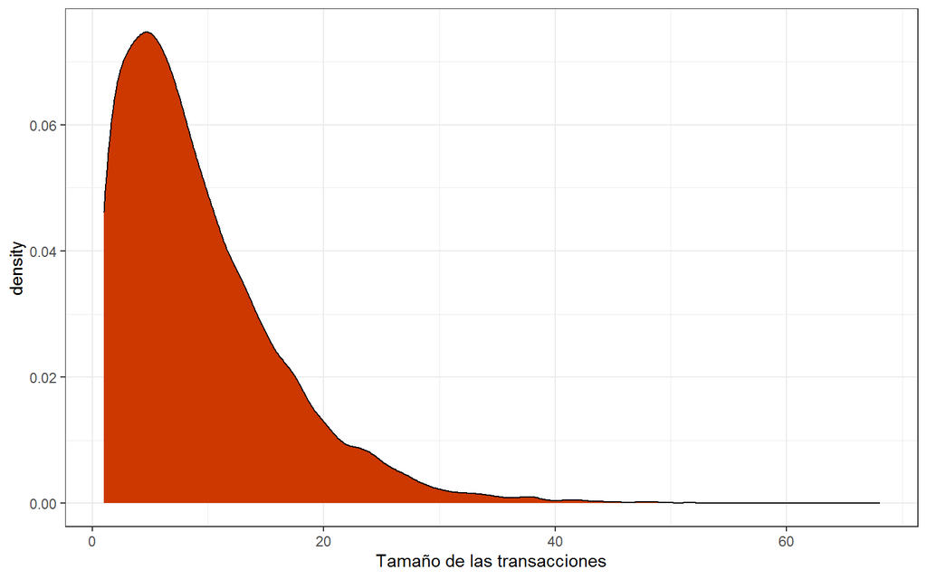

```
##
##  Lilliefors (Kolmogorov-Smirnov) normality test
##
## data:  tamanhos_trans$tamaño
## D = 0.13013, p-value < 2.2e-16
```

```
##   0%  10%  20%  30%  40%  50%  60%  70%  80%  90% 100%
##    1    2    3    5    6    8    9   11   14   19   68
```

```
##      tamaño
##  Min.   : 1.000
##  1st Qu.: 4.000
##  Median : 8.000
##  Mean   : 9.354
##  3rd Qu.:13.000
##  Max.   :68.000
```

Además como se observa en los resultados anteriores, se tiene que en el número mayor de productos que se han comprado en una transacción es 68, también se tiene que el 70% de las transacciones se han adquirido como máximo 11 productos y en el 50% de las transacciones se adquieren 8 productos.

El siguiente análisis básico consiste en identificar cuáles son los items más frecuentes (los que tienen mayor soporte) dentro del conjunto de todas las transacciones. Con la función itemFrequency() se puede extraer esta información de un objeto tipo transactions. El nombre de esta función puede causar confusión. Por “frecuencia” se hace referencia al soporte de cada item, que es la fracción de transacciones que contienen dicho item respecto al total de todas las transacciones.

```
##                 Banana Bag of Organic Bananas   Organic Strawberries
##                0.13744                0.11272                0.07536
##   Organic Baby Spinach   Organic Hass Avocado
##                0.07248                0.06472
```

Como se observa en la tabla anterior el mayor soporte que tienen los productos es encabezado por Banana y es de 0.14

Ahora se procede a observar el número de transacciones en las que aparece cada ítemen para ello se indica el argumento type = "absolute" en la función itemFrequency(), así se tiene:

```
##                 Banana Bag of Organic Bananas   Organic Strawberries
##                   1718                   1409                    942
##   Organic Baby Spinach   Organic Hass Avocado
##                    906                    809
```

Por tanto analizando la tabla de soporte y la de transacciones de los productos, en ambos casos el alimento que mas compra la gente es Banana y aparece en 1718 transacciones, es por eso que su soporte es el mas alto.

Continuando con el anális de reglas de asociación para la base de datos, es necesario recalcar que se debe encontrar patrones frecuentes, es decir se procederá a eliminar aquellas transacciones donde se haya adquirido un solo producto.

```
## [1] 11733 17917
```

Donde al final se trabajará con 11733 transacciones, ya que se han reducido 767 por lo que solo habían comprado un producto.

## Umbral y soporte de confianza

Como bien se explico en la introducción el soporte hace referencia al número de transacciones que contienen un itemset dividido entre el total de transacciones, por lo que debido a la altas dimensiones de la base, el soporte tendrá que ser pequeño, así es que para este caso se considerata que un cojunto de items es frecuente si aparece en al menos en 15 transacciones y finalmente se establecerá una confianza del 70%.

```
## [1] 0.001278445
```

```
## [1] 0.7
```

Es así que se tiene un soporte de 0.0012 y una confianza de 0.7.

## Obtención de Ítems frecuentes por algoritmo A priori

Con la función apriori() se puede aplicar el algoritmo Apriori a un objeto de tipo transactions y extraer tanto itemsets frecuentes como reglas de asociación que superen un determinado soporte y confianza.

```
## set of 2590 itemsets
##
## most frequent items:
##                 Banana Bag of Organic Bananas   Organic Strawberries
##                    218                    174                    148
##   Organic Baby Spinach   Organic Hass Avocado                (Other)
##                    138                    126                   3170
##
## element (itemset/transaction) length distribution:sizes
##    1    2    3
## 1314 1168  108
##
##    Min. 1st Qu.  Median    Mean 3rd Qu.    Max.
##   1.000   1.000   1.000   1.534   2.000   3.000
##
## summary of quality measures:
##     support         transIdenticalToItemsets     count
##  Min.   :0.001364   Min.   :0.000e+00        Min.   :  16.00
##  1st Qu.:0.001619   1st Qu.:0.000e+00        1st Qu.:  19.00
##  Median :0.002131   Median :0.000e+00        Median :  25.00
##  Mean   :0.003504   Mean   :4.472e-05        Mean   :  41.11
##  3rd Qu.:0.003324   3rd Qu.:8.523e-05        3rd Qu.:  39.00
##  Max.   :0.145743   Max.   :2.557e-03        Max.   :1710.00
##
## includes transaction ID lists: FALSE
##
## mining info:
##           data ntransactions     support confidence
##  transacciones         11733 0.001278445          1
```

## Obtención de Ítems frecuentes por algoritmo Eclat

Con la función ecalt() se tiene los itemsets frecuentes como reglas de asociación que superen un determinado soporte y confianza.

```
## set of 1276 itemsets
##
## most frequent items:
##                 Banana Bag of Organic Bananas   Organic Strawberries
##                    217                    173                    147
##   Organic Baby Spinach   Organic Hass Avocado                (Other)
##                    137                    125                   1861
##
## element (itemset/transaction) length distribution:sizes
##    2    3
## 1168  108
##
##    Min. 1st Qu.  Median    Mean 3rd Qu.    Max.
##   2.000   2.000   2.000   2.085   2.000   3.000
##
## summary of quality measures:
##     support         transIdenticalToItemsets     count
##  Min.   :0.001364   Min.   : 16.00           Min.   : 16.00
##  1st Qu.:0.001534   1st Qu.: 18.00           1st Qu.: 18.00
##  Median :0.001875   Median : 22.00           Median : 22.00
##  Mean   :0.002505   Mean   : 29.39           Mean   : 29.39
##  3rd Qu.:0.002727   3rd Qu.: 32.00           3rd Qu.: 32.00
##  Max.   :0.019688   Max.   :231.00           Max.   :231.00
##
## includes transaction ID lists: FALSE
##
## mining info:
##           data ntransactions     support
##  transacciones         11733 0.001278445
```

## Los items con mayor soporte

```
##     items                    support    transIdenticalToItemsets count
## [1] {Banana}                 0.14574278 0.0025568908             1710
## [2] {Bag of Organic Bananas} 0.11957726 0.0019602830             1403
## [3] {Organic Strawberries}   0.08003068 0.0007670672              939
## [4] {Organic Baby Spinach}   0.07628058 0.0006818376              895
## [5] {Organic Hass Avocado}   0.06878036 0.0004261485              807
## [6] {Organic Avocado}        0.05284241 0.0005966079              620
```

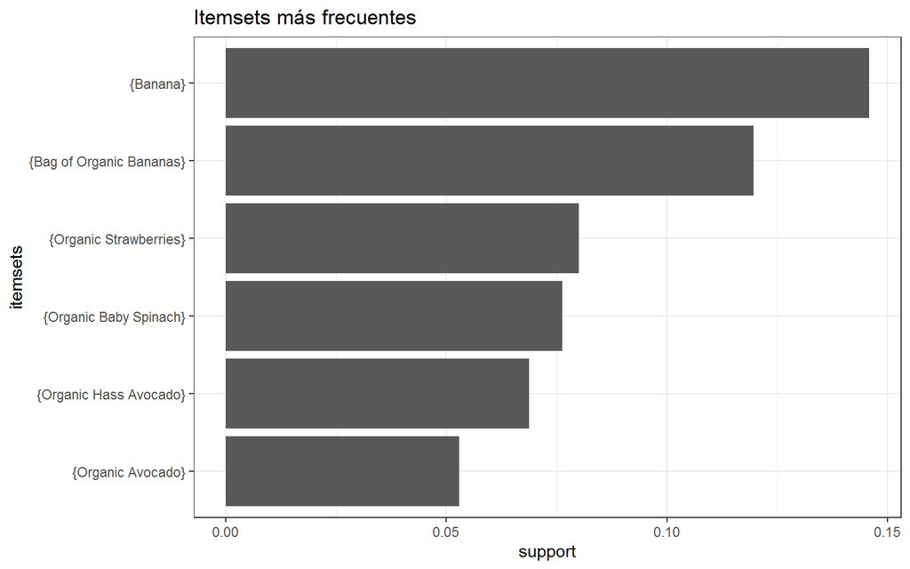

En el gráfico anterior se observa de mejor manera que el producto que mas está en las transacciones es Banana.

## Filtrado de itemsets

Una vez que los itemsets frecuentes han sido identificados mediante el algoritmo Apripori, pueden ser filtrados con la función subset(). Esta función recibe dos argumentos: un objeto itemset o rules y una condición lógica que tienen que cumplir las reglas/itemsets para ser seleccionados.

A manera de ejemplo Se procede a identificar aquellos itemsets frecuentes que contienen el item Organic Avocado .

```
## set of 81 itemsets
```

```
##     items                                                support transIdenticalToItemsets count
## [1] {Organic Avocado}                                0.052842410             0.0005966079   620
## [2] {Organic Avocado,
##      Organic Coconut Milk}                           0.001363675             0.0000000000    16
## [3] {Organic Avocado,
##      Organic Red Radish, Bunch}                      0.001363675             0.0000000000    16
## [4] {Organic Avocado,
##      Unsweetened Original Almond Breeze Almond Milk} 0.001448905             0.0000000000    17
## [5] {Feta Cheese Crumbles,
##      Organic Avocado}                                0.001448905             0.0000000000    17
```

```
## set of 11 itemsets
```

```
##     items                                   support transIdenticalToItemsets count
## [1] {Banana,
##      Organic Avocado}                   0.015852723             8.522969e-05   186
## [2] {Banana,
##      Organic Avocado,
##      Organic Peeled Whole Baby Carrots} 0.001363675             0.000000e+00    16
## [3] {Banana,
##      Organic Avocado,
##      Red Vine Tomato}                   0.001363675             0.000000e+00    16
## [4] {Banana,
##      Honeycrisp Apple,
##      Organic Avocado}                   0.001363675             0.000000e+00    16
## [5] {Banana,
##      Cucumber Kirby,
##      Organic Avocado}                   0.002471661             0.000000e+00    29
```

Puede observarse que muchos itemsets están a su vez contenidos en itemsets de orden superior, es decir, existen itemsets que son subsets de otros. Para identificar cuáles son, o cuales no lo son, se puede emplear la función is.subset(). Encontrar los itemsets que son subsets de otros itemsets implica comparar todos los pares de itemsets y determinar si uno está contenido en el otro. La función is.subset() realiza comparaciones entre dos conjuntos de itemsets y devuelve una matriz lógica que determina si el itemset de la fila está contenido en cada itemset de las columnas.

Para conocer el total de itemsets que son subsets de otros itemsets se cuenta el número total de TRUE en la matriz resultante.

```
## [1] 5574
```

## Obtención de reglas de Asociación

Para crear las reglas de asociación se sigue el mismo proceso que para obtener itemsets frecuentes pero, además de especificar un soporte mínimo, se tiene que establecer una confianza mínima para que una regla se incluya en los resultados. En este caso, se emplea una confianza mínima del 70%.

### Algoritmo A priori

```
## [1] "Reglas generadas: 7"
```

```
## set of 7 rules
##
## rule length distribution (lhs + rhs):sizes
## 2 3
## 2 5
##
##    Min. 1st Qu.  Median    Mean 3rd Qu.    Max.
##   2.000   2.500   3.000   2.714   3.000   3.000
##
## summary of quality measures:
##     support           confidence        coverage             lift
##  Min.   :0.001364   Min.   :0.7143   Min.   :0.001449   Min.   : 34.41
##  1st Qu.:0.001364   1st Qu.:0.7560   1st Qu.:0.001747   1st Qu.:161.45
##  Median :0.001364   Median :0.7619   Median :0.001790   Median :258.82
##  Mean   :0.001485   Mean   :0.7913   Mean   :0.001899   Mean   :227.92
##  3rd Qu.:0.001577   3rd Qu.:0.8048   3rd Qu.:0.002088   3rd Qu.:322.03
##  Max.   :0.001790   Max.   :0.9412   Max.   :0.002386   Max.   :335.23
##      count
##  Min.   :16.00
##  1st Qu.:16.00
##  Median :16.00
##  Mean   :17.43
##  3rd Qu.:18.50
##  Max.   :21.00
##
## mining info:
##           data ntransactions     support confidence
##  transacciones         11733 0.001278445        0.7
```

```
##     lhs                                                        rhs                                                         support confidence    coverage      lift count
## [1] {Blueberry Whole Milk Yogurt Pouch,
##      Yotoddler Organic Pear Spinach Mango Yogurt}           => {Organic Whole Milk Strawberry Beet Berry Yogurt Pouch} 0.001363675  0.9411765 0.001448905 324.78893    16
## [2] {Lime Sparkling Water,
##      Pure Sparkling Water}                                  => {Sparkling Water Grapefruit}                            0.001448905  0.8095238 0.001789824  34.41356    17
## [3] {Blueberry Whole Milk Yogurt Pouch,
##      Organic Whole Milk Strawberry Beet Berry Yogurt Pouch} => {Yotoddler Organic Pear Spinach Mango Yogurt}           0.001363675  0.8000000 0.001704594 335.22857    16
## [4] {Organic Whole Milk Strawberry Beet Berry Yogurt Pouch,
##      Yotoddler Organic Pear Spinach Mango Yogurt}           => {Blueberry Whole Milk Yogurt Pouch}                     0.001363675  0.7619048 0.001789824 319.26531    16
## [5] {Total 2% Lowfat Greek Strained Yogurt With Blueberry,
##      Total 2% Lowfat Greek Strained Yogurt with Peach}      => {Total 2% with Strawberry Lowfat Greek Strained Yogurt} 0.001363675  0.7619048 0.001789824  76.40537    16
## [6] {Yotoddler Organic Pear Spinach Mango Yogurt}           => {Organic Whole Milk Strawberry Beet Berry Yogurt Pouch} 0.001789824  0.7500000 0.002386431 258.81618    21
## [7] {Blueberry Whole Milk Yogurt Pouch}                     => {Organic Whole Milk Strawberry Beet Berry Yogurt Pouch} 0.001704594  0.7142857 0.002386431 246.49160    20
```

### Algoritmo Eclat

```
## [1] "Reglas generadas: 7"
```

```
## set of 7 rules
##
## rule length distribution (lhs + rhs):sizes
## 2 3
## 2 5
##
##    Min. 1st Qu.  Median    Mean 3rd Qu.    Max.
##   2.000   2.500   3.000   2.714   3.000   3.000
##
## summary of quality measures:
##     support           confidence          lift           itemset
##  Min.   :0.001364   Min.   :0.7143   Min.   : 34.41   Min.   :  2.00
##  1st Qu.:0.001364   1st Qu.:0.7560   1st Qu.:161.45   1st Qu.:  2.00
##  Median :0.001364   Median :0.7619   Median :258.82   Median :  3.00
##  Mean   :0.001485   Mean   :0.7913   Mean   :227.92   Mean   : 36.57
##  3rd Qu.:0.001577   3rd Qu.:0.8048   3rd Qu.:322.03   3rd Qu.: 27.00
##  Max.   :0.001790   Max.   :0.9412   Max.   :335.23   Max.   :193.00
##
## mining info:
##           data ntransactions     support confidence
##  transacciones         11733 0.001278445        0.7
```

las reglas ordenadas son:

```
##     lhs                                                        rhs                                                         support confidence      lift itemset
## [1] {Blueberry Whole Milk Yogurt Pouch,
##      Yotoddler Organic Pear Spinach Mango Yogurt}           => {Organic Whole Milk Strawberry Beet Berry Yogurt Pouch} 0.001363675  0.9411765 324.78893       2
## [2] {Lime Sparkling Water,
##      Pure Sparkling Water}                                  => {Sparkling Water Grapefruit}                            0.001448905  0.8095238  34.41356     193
## [3] {Blueberry Whole Milk Yogurt Pouch,
##      Organic Whole Milk Strawberry Beet Berry Yogurt Pouch} => {Yotoddler Organic Pear Spinach Mango Yogurt}           0.001363675  0.8000000 335.22857       2
## [4] {Organic Whole Milk Strawberry Beet Berry Yogurt Pouch,
##      Yotoddler Organic Pear Spinach Mango Yogurt}           => {Blueberry Whole Milk Yogurt Pouch}                     0.001363675  0.7619048 319.26531       2
## [5] {Total 2% Lowfat Greek Strained Yogurt With Blueberry,
##      Total 2% Lowfat Greek Strained Yogurt with Peach}      => {Total 2% with Strawberry Lowfat Greek Strained Yogurt} 0.001363675  0.7619048  76.40537      49
## [6] {Yotoddler Organic Pear Spinach Mango Yogurt}           => {Organic Whole Milk Strawberry Beet Berry Yogurt Pouch} 0.001789824  0.7500000 258.81618       5
## [7] {Blueberry Whole Milk Yogurt Pouch}                     => {Organic Whole Milk Strawberry Beet Berry Yogurt Pouch} 0.001704594  0.7142857 246.49160       3
```

## Evaluación de las reglas

Además de la confianza y el soporte, existen otras métricas que permiten cuantificar la calidad de las reglas y la probabilidad de que reflejen relaciones reales. Algunas de las más empleadas son: Lift,Coverage y Fisher exact test.

Para el caso de Lift, se tiene que es de 34,41 y mientras más alejado esté del uno más evidencias de que la regla no se debe a un artefacto aleatorio, es decir, mayor la evidencia de que la regla representa un patrón real.

## Filtrado de reglas

Cuando se crean reglas de asociación, pueden ser interesantes únicamente aquellas que contienen un determinado conjunto de items en el antecedente o en el consecuente. Con arules existen varias formas de seleccionar solo determinadas reglas.

### Restringir las reglas que se crean

Una vez obtenidas las reglas, tenemos la posibilidad de establecer restricciones o filtros. Por ejemplo, para manterner solo las que contengan “Blueberry Whole Milk Yogurt Pouch” en el antecedente, con una confianza superior al 90%:

#### A priori

```
##     lhs                                              rhs                                                         support confidence    coverage     lift count
## [1] {Blueberry Whole Milk Yogurt Pouch,
##      Yotoddler Organic Pear Spinach Mango Yogurt} => {Organic Whole Milk Strawberry Beet Berry Yogurt Pouch} 0.001363675  0.9411765 0.001448905 324.7889    16
```

#### Eclat

```
##     lhs                                              rhs                                                         support confidence     lift itemset
## [1] {Blueberry Whole Milk Yogurt Pouch,
##      Yotoddler Organic Pear Spinach Mango Yogurt} => {Organic Whole Milk Strawberry Beet Berry Yogurt Pouch} 0.001363675  0.9411765 324.7889       2
```

### Filtrar reglas creadas

También es posible filtrar las reglas una vez que han sido creadas. Por ejemplo, se procede a filtrar aquellas reglas que contienen Blueberry Whole Milk Yogurt Pouch,Organic Whole Milk Strawberry Beet Berry Yogurt Pouch

#### A priori

```
##     lhs                                                        rhs                                               support confidence    coverage     lift count
## [1] {Blueberry Whole Milk Yogurt Pouch,
##      Organic Whole Milk Strawberry Beet Berry Yogurt Pouch} => {Yotoddler Organic Pear Spinach Mango Yogurt} 0.001363675        0.8 0.001704594 335.2286    16
```

#### Eclat

```
##     lhs                                                        rhs                                               support confidence     lift itemset
## [1] {Blueberry Whole Milk Yogurt Pouch,
##      Organic Whole Milk Strawberry Beet Berry Yogurt Pouch} => {Yotoddler Organic Pear Spinach Mango Yogurt} 0.001363675        0.8 335.2286       2
```

### Reglas maximales

Un itemset es maximal si no existe otro itemset que sea su superset. Una regla de asociación se define como regla maximal si está generada con un itemset maximal. Con la función is.maximal() se pueden identificar las reglas maximales.

#### A priori

```
## set of 5 rules
```

```
##     lhs                                                        rhs                                                         support confidence    coverage      lift count
## [1] {Blueberry Whole Milk Yogurt Pouch,
##      Yotoddler Organic Pear Spinach Mango Yogurt}           => {Organic Whole Milk Strawberry Beet Berry Yogurt Pouch} 0.001363675  0.9411765 0.001448905 324.78893    16
## [2] {Blueberry Whole Milk Yogurt Pouch,
##      Organic Whole Milk Strawberry Beet Berry Yogurt Pouch} => {Yotoddler Organic Pear Spinach Mango Yogurt}           0.001363675  0.8000000 0.001704594 335.22857    16
## [3] {Organic Whole Milk Strawberry Beet Berry Yogurt Pouch,
##      Yotoddler Organic Pear Spinach Mango Yogurt}           => {Blueberry Whole Milk Yogurt Pouch}                     0.001363675  0.7619048 0.001789824 319.26531    16
## [4] {Total 2% Lowfat Greek Strained Yogurt With Blueberry,
##      Total 2% Lowfat Greek Strained Yogurt with Peach}      => {Total 2% with Strawberry Lowfat Greek Strained Yogurt} 0.001363675  0.7619048 0.001789824  76.40537    16
## [5] {Lime Sparkling Water,
##      Pure Sparkling Water}                                  => {Sparkling Water Grapefruit}                            0.001448905  0.8095238 0.001789824  34.41356    17
```

#### Eclat

```
## set of 5 rules
```

```
##     lhs                                                       rhs                                                         support confidence    coverage      lift count
## [1] {Blueberry Whole Milk Yogurt Pouch}                    => {Organic Whole Milk Strawberry Beet Berry Yogurt Pouch} 0.001704594  0.7142857 0.002386431 246.49160    20
## [2] {Yotoddler Organic Pear Spinach Mango Yogurt}          => {Organic Whole Milk Strawberry Beet Berry Yogurt Pouch} 0.001789824  0.7500000 0.002386431 258.81618    21
## [3] {Blueberry Whole Milk Yogurt Pouch,
##      Yotoddler Organic Pear Spinach Mango Yogurt}          => {Organic Whole Milk Strawberry Beet Berry Yogurt Pouch} 0.001363675  0.9411765 0.001448905 324.78893    16
## [4] {Total 2% Lowfat Greek Strained Yogurt With Blueberry,
##      Total 2% Lowfat Greek Strained Yogurt with Peach}     => {Total 2% with Strawberry Lowfat Greek Strained Yogurt} 0.001363675  0.7619048 0.001789824  76.40537    16
## [5] {Lime Sparkling Water,
##      Pure Sparkling Water}                                 => {Sparkling Water Grapefruit}                            0.001448905  0.8095238 0.001789824  34.41356    17
```

Es así como 5 de las siete reglas son maximales.

### Reglas redundantes

Dos reglas son idénticas si tienen el mismo antecedente (parte izquierda) y consecuente (parte derecha). Supóngase ahora que una de estas reglas tiene en su antecedente los mismos items que forman el antecedente de la otra, junto con algunos items más. La regla más genérica se considera redundante, ya que no aporta información adicional. En concreto, se considera que una regla $X \rightarrow Y$ es redundante si existe un subset $X’$ tal que existe una regla $X’ \rightarrow Y$ cuyo soporte es mayor.

$X \rightarrow Y$ es redundante si existe un subset $X’$ tal que: $conf(X’ \rightarrow Y) >= conf(X \rightarrow Y)$

```
## set of 0 rules
```

Como se observa existen cero reglas redundantes en este caso.

## Visualización

[output not shown]

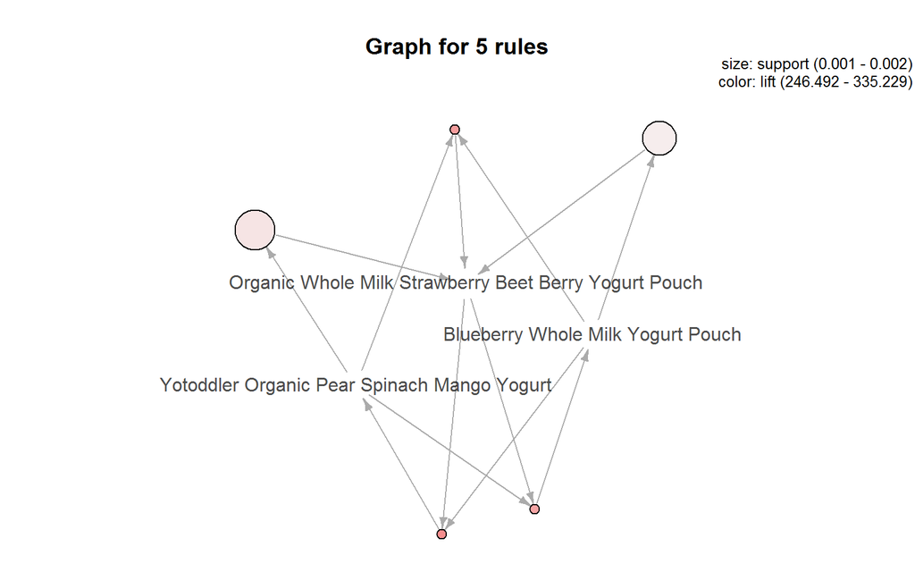

Para una mejor visualización de las reglas se procede a realizar un gráfico tipo grafo y se tiene lo siguiente: en una primera instancia la gente compra productos para dieta y estos son: si compra Leche entera y fresas entonces también comprará pera orgánica, otro caso importante es el de la compra de compra de espinacas y fresas entonces la persona también compra leche entera, así se puede deducir que los clientes que compran estos productos en su mayoría son clientes con buena salud debido a que siguen una dieta estricta en bajas calorías y productos orgánicos.

# Preguntas del Taller

## Con base en los resultados de la minería y las medidas de evaluación del patrón discutidas en este capítulo, discuta qué medida puede descubrir de manera convincente patrones de compras.

Además de la confianza y el soporte, existen otras métricas que permiten cuantificar la calidad de las reglas y la probabilidad de que reflejen relaciones reales. Algunas de las más empleadas son:

### Lift:

El estadístico lift compara la frecuencia observada de una regla con la frecuencia esperada simplemente por azar (si la regla no existe realmente). El valor lift de una regla “si $X$, entonces $Y$” se obtiene acorde a la siguiente ecuación:

$lift=\frac{soporte(X \cup Y)}{soporte(X) *soporte (Y)}$

Cuanto más se aleje el valor de lift de 1, más evidencias de que la regla no se debe a un artefacto aleatorio, es decir, mayor la evidencia de que la regla representa un patrón real.

```
## set of 7 rules
##
## rule length distribution (lhs + rhs):sizes
## 2 3
## 2 5
##
##    Min. 1st Qu.  Median    Mean 3rd Qu.    Max.
##   2.000   2.500   3.000   2.714   3.000   3.000
##
## summary of quality measures:
##     support           confidence        coverage             lift
##  Min.   :0.001364   Min.   :0.7143   Min.   :0.001449   Min.   : 34.41
##  1st Qu.:0.001364   1st Qu.:0.7560   1st Qu.:0.001747   1st Qu.:161.45
##  Median :0.001364   Median :0.7619   Median :0.001790   Median :258.82
##  Mean   :0.001485   Mean   :0.7913   Mean   :0.001899   Mean   :227.92
##  3rd Qu.:0.001577   3rd Qu.:0.8048   3rd Qu.:0.002088   3rd Qu.:322.03
##  Max.   :0.001790   Max.   :0.9412   Max.   :0.002386   Max.   :335.23
##      count
##  Min.   :16.00
##  1st Qu.:16.00
##  Median :16.00
##  Mean   :17.43
##  3rd Qu.:18.50
##  Max.   :21.00
##
## mining info:
##           data ntransactions     support confidence
##  transacciones         11733 0.001278445        0.7
```

Como se observa en el summary de reglas, se tiene que el lift mínimo es de 34,41, por tanto la evidencia es mayor de que las reglas presenten un patrón real

### Test de fisher

Fisher exact test: devuelve el p-value asociado a la probabilidad de observar la regla solo por azar.

Se puede calcular el test de fisher para obtener si las reglas representan patrones reales así se tiene:

#### A priori

```
##      Min.   1st Qu.    Median      Mean   3rd Qu.      Max.
## 0.000e+00 0.000e+00 0.000e+00 9.942e-26 3.220e-29 6.959e-25
```

```
##      coverage fishersExactTest
## 1 0.002386431     4.336595e-48
## 2 0.002386431     1.977946e-51
## 3 0.001448905     6.131161e-42
## 4 0.001704594     2.406139e-41
## 5 0.001789824     1.009604e-40
## 6 0.001789824     6.444803e-29
## 7 0.001789824     6.959046e-25
```

#### Eclat

```
##      Min.   1st Qu.    Median      Mean   3rd Qu.      Max.
## 0.000e+00 0.000e+00 0.000e+00 9.942e-26 3.220e-29 6.959e-25
```

```
##      coverage fishersExactTest
## 1 0.001789824     1.009604e-40
## 2 0.001448905     6.131161e-42
## 3 0.001704594     2.406139e-41
## 4 0.002386431     4.336595e-48
## 5 0.002386431     1.977946e-51
## 6 0.001789824     6.444803e-29
## 7 0.001789824     6.959046e-25
```

Como se observa en la tabla anterior los p-valores son muy pequeños, por lo que es probable que las reglas reflejen patrones de comportamiento en los pedidos más acercados a la realidad